# Headphones, do people really use them?

[figure not shown]

Headphones and Locations

This data looks at how many people wear headphones in different locations. It helps give context for audio producers who want to understand how people actually listen to audio in everyday settings whether it’s music, podcasts, or audiobooks. With the help of three of my friends I collected observational data from 5 different locations.

## Are people wearing more headphones in certain location?

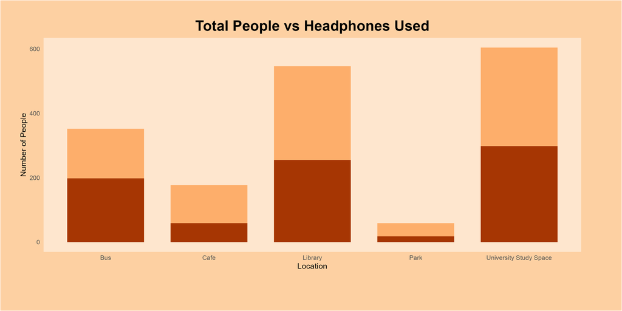

The darker color represents people using headphones in these locations and the combined color represents the total amount of people in that observed location. In this visualization I noticed that university study space and the bus tended to have more people listening to music. So location definitely plays a part on whether people tend to listen with their headphones.

## Does time matter if they were headphones or not?

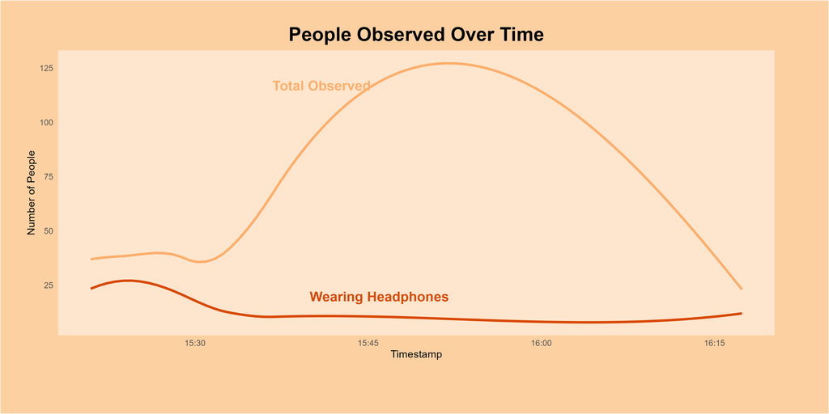

Observed Overtime

I explored another dataset by logging timestamps and observing whether people tended to wear headphones. I noticed that even though some locations had more people, overall, this didn’t necessarily mean more people were wearing headphones. This could be influenced by when the observations were made or by external factors such as nearby events or specific times of day. To get a more accurate representation of headphone usage over time, more data would need to be collected at consistent intervals across the same locations.

## Overall Tally of Headphones vs Observed

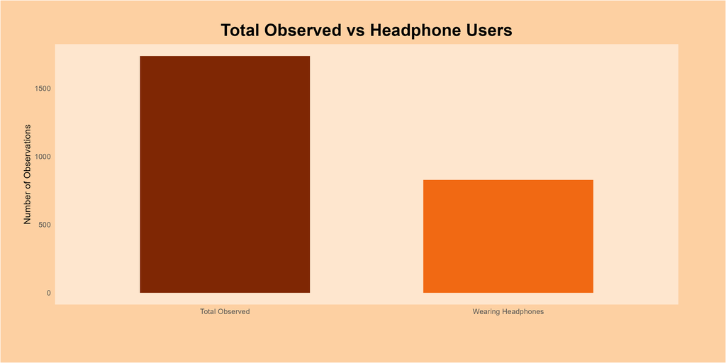

Total counts

The final visualization represents the overall totals, helping to generalize the data across all locations. It shows regardless of where the observations took place how many people were actually wearing headphones. In this case, nearly half of the total people observed were wearing headphones. This supports the central idea that overall, headphone usage is common and people do seem to be regularly listening to audio.

## In conclusion

Overall, I found that people are more likely to wear headphones in indoor spaces like buses and university study areas. In general, a lot of people across all locations were wearing headphones, which shows that listening to audio whether it’s music, podcasts, or audiobooks is common. This makes headphone use something worth thinking about for anyone creating audio content. It would be a great addition to collect more data at different times and places to see if these patterns hold up.